# Sampling and Distributions in R

## 1. Sampling

### Drawing from a Vector

In the below code, we draw numbers from a vector

```r
numbers = 1:3

numbers %>%
  sample(size = 10,
         replace = T)
```

```
 [1] 2 2 3 3 1 2 2 3 2 3
```

Use the prob = argument to change the probability with which each number should be drawn.

```r
numbers = 1:3

numbers %>%
  sample(size = 10,
         replace = T,
         prob = c(0.8, 0.1, 0.1))
```

```
 [1] 1 1 1 1 1 1 1 2 3 1
```

Make sure to set the seed in order to make your code reproducible. The code chunk below may give a different outcome each time is run.

```r
numbers = 1:5

numbers %>%
  sample(5)
```

```
[1] 4 1 2 3 5
```

adding set.seed(1) to the above code will produce the same output everytime the code is run!

### Working with distributions

R provides four functions for each distribution (using “norm” as an example):

- `dnorm()` - Density/probability function
- `pnorm()` - Cumulative distribution function
- `qnorm()` - Quantile function (inverse CDF)
- `rnorm()` - Random samples

### Plotting Distributions

Here’s an easy way to plot distributions in ggplot2 using the stat_function() function. We take a look at a normal distribution of height (in cm) with mean = 180 and sd = 10

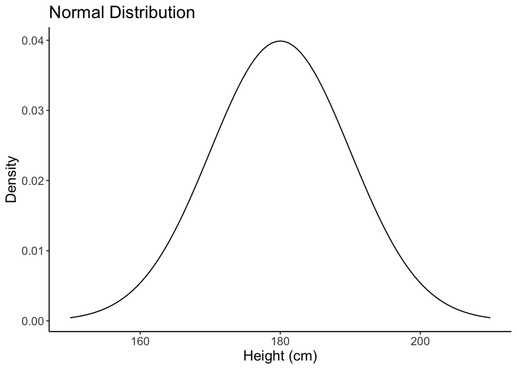

```r
ggplot(data = tibble(height = c(150, 210)), aes(x = height)) +
  stat_function(fun = ~ dnorm(., mean = 180, sd = 10)) +
  labs(x = "Height (cm)", y = "Density", title = "Normal Distribution")
```

Note that the data frame I=we created with tibble() only needs to have the minimum and the maximum value of the x-range that we are interested in. Here, I chose 150 and 210 as the minimum and maximum, respectively (which is the mean +/- 3 standard deviations).

### Sampling from Distributions

For each distribution, R provides a way of sampling random number from this distribution. For the normal distribution, we can use the rnorm() function to take random samples.

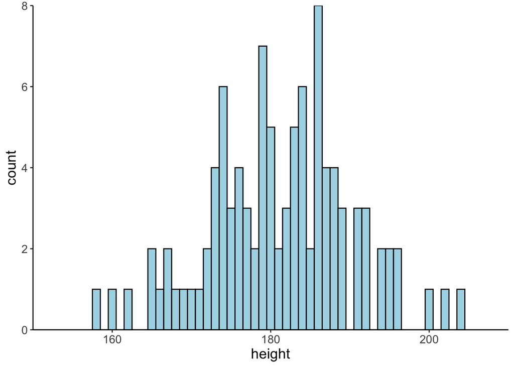

```r
# make this example reproducible
set.seed(1)

# define how many samples to draw
tmp.nsamples = 100

# make a data frame with the samples
df.plot = tibble(height = rnorm(n = tmp.nsamples,
                                mean = 180,
                                sd = 10))

# plot the samples using a histogram
ggplot(data = df.plot,
       mapping = aes(x = height)) +
  geom_histogram(binwidth = 1,
                 color = "black",
                 fill = "lightblue") +
  scale_x_continuous(breaks = c(160, 180, 200)) +
  coord_cartesian(xlim = c(150, 210),
                  expand = F)

# remove all variables with tmp in their name
rm(list = ls() %>%
     str_subset(pattern = "tmp."))
```

Let’s see how many samples it takes to closely approximate the shape of the normal distribution with our histogram of samples.

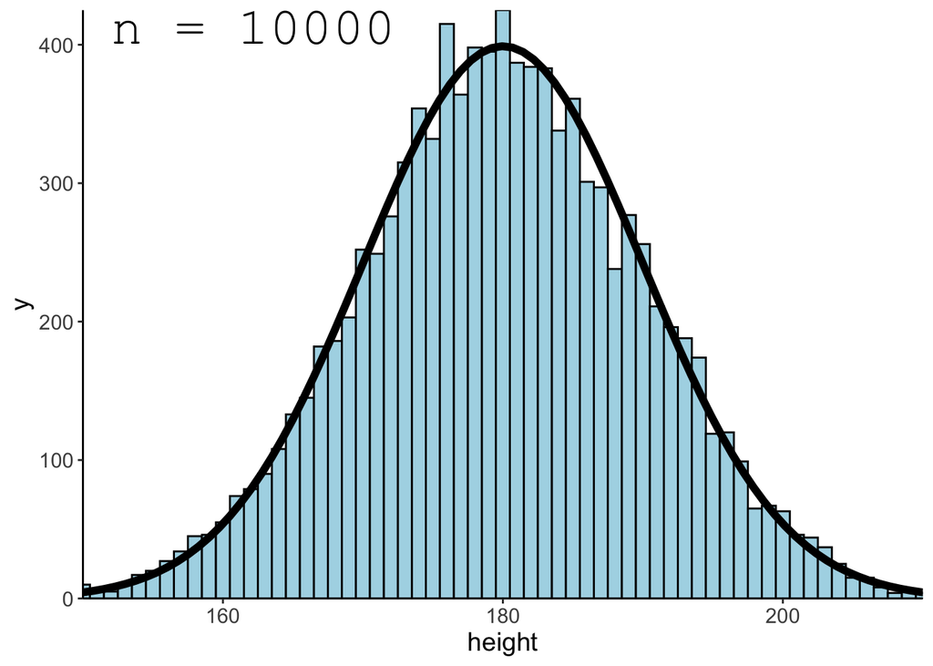

```r
# make this example reproducible
set.seed(1)

# play around with this value
# tmp.nsamples = 100
tmp.nsamples = 10000
tmp.binwidth = 1

# make a data frame with the samples
df.plot = tibble(height = rnorm(n = tmp.nsamples,
                                mean = 180,
                                sd = 10))

# adjust the density of the normal distribution based on the samples and binwidth
fun.dnorm = function(x, mean, sd, n, binwidth){
  dnorm(x = x, mean = mean, sd = sd) * n * binwidth
}

# plot the samples using a histogram
ggplot(data = df.plot,
       mapping = aes(x = height)) +
  geom_histogram(binwidth = tmp.binwidth,
                 color = "black",
                 fill = "lightblue") +
  stat_function(fun = ~ fun.dnorm(x = .,
                                  mean = 180,
                                  sd = 10,
                                  n = tmp.nsamples,
                                  binwidth = tmp.binwidth),
                xlim = c(min(df.plot$height), max(df.plot$height)),
                linewidth = 2) +
  annotate(geom = "text",
           label = str_c("n = ", tmp.nsamples),
           x = -Inf,
           y = Inf,
           hjust = -0.1,
           vjust = 1.1,
           size = 10,
           family = "Courier New") +
  scale_x_continuous(breaks = c(160, 180, 200)) +
  coord_cartesian(xlim = c(150, 210),
                  expand = F)

# remove all variables with tmp in their name
rm(list = ls() %>%
     str_subset(pattern = "tmp."))
```

## 3. Computing Probabilities

## Method 1

To find P(170 < Height < 180), we use the cumulative distribution function `pnorm()`:  
**P(170 < X < 180) = P(X ≤ 180) - P(X ≤ 170)**

```r
lower <- 170
upper <- 180
prob <- pnorm(upper, mean = 180, sd = 10) - pnorm(lower, mean = 180, sd = 10)
print(paste("P(170 < X < 180) =", round(prob, 4)))
```

```
[1] "P(170 < X < 180) = 0.3413"
```

We can visualize this as the shaded area under the curve:

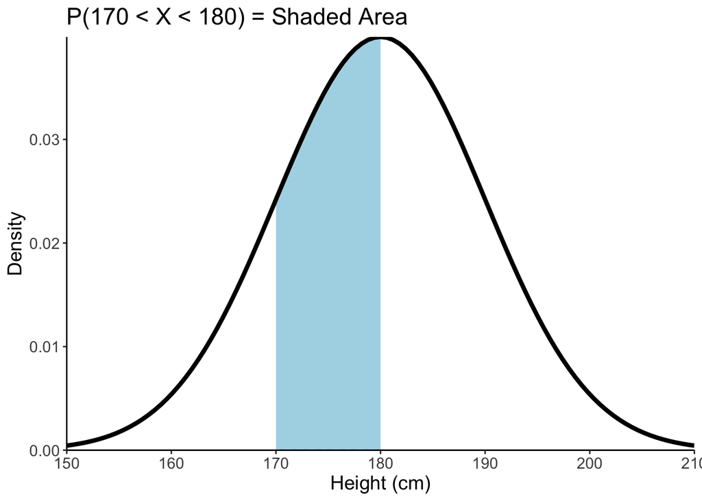

```r
tibble(height = c(150, 210)) %>%
  ggplot(aes(x = height)) +
  stat_function(fun = ~ dnorm(., mean = 180, sd = 10),
                geom = "area", fill = "lightblue", xlim = c(170, 180),
                color = "black", linetype = 2) +
  stat_function(fun = ~ dnorm(., mean = 180, sd = 10), linewidth = 1.5) +
  labs(x = "Height (cm)", y = "Density",
       title = "P(170 < X < 180) = Shaded Area") +
  coord_cartesian(xlim = c(150, 210), expand = FALSE)
```

## Method 2

Instead of using the mathematical formula, we can **generate random samples** from the distribution and count how many fall in our range:

```r
set.seed(1)

# Generate 10,000 random heights from the normal distribution
df_samples <- tibble(height = rnorm(10000, mean = 180, sd = 10))

# Count how many fall between 170 and 180
prob_simulation <- df_samples %>%
  filter(height >= 170, height <= 180) %>%
  summarize(prob = n() / 10000) %>%
  pull(prob)

print(paste("P(170 < X < 180) =", round(prob_simulation, 4)))
```

```
[1] "P(170 < X < 180) = 0.3461"
```

We can visualize this as bars in a histogram:

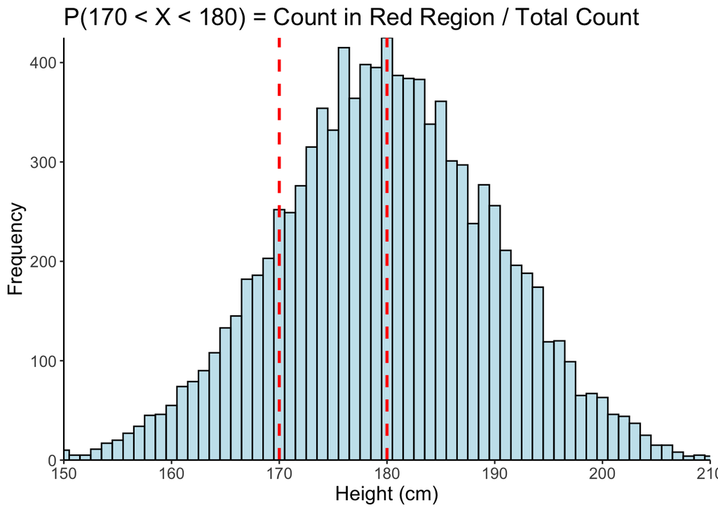

```r
df_samples %>%
  ggplot(aes(x = height)) +
  geom_histogram(binwidth = 1, color = "black", fill = "lightblue", alpha = 0.7) +
  geom_vline(xintercept = 170, color = "red", linewidth = 1, linetype = 2) +
  geom_vline(xintercept = 180, color = "red", linewidth = 1, linetype = 2) +
  labs(x = "Height (cm)", y = "Frequency",
       title = "P(170 < X < 180) = Count in Red Region / Total Count") +
  coord_cartesian(xlim = c(150, 210), expand = FALSE)
```

## 4. Central Limit Theorem

The CLT states that the distribution of sample means approaches a normal distribution, regardless of the underlying distribution’s shape. Here’s a demonstration:

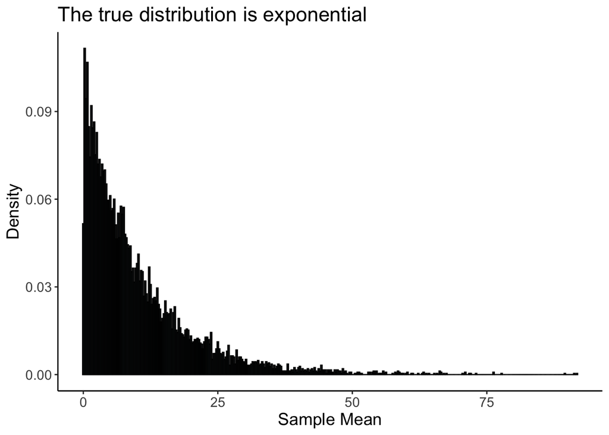

```r
set.seed(1)

# Generate 10000 sample means (each from 1 observation, to show the true distribution)
tibble(sample_mean = replicate(10000, {
  rexp(1, rate = 0.1) %>% mean()
})) %>%
  ggplot(aes(x = sample_mean)) +
  geom_histogram(aes(y = after_stat(density)), binwidth = 0.25,
                 color = "black", fill = "lightblue", alpha = 0.7) +
  labs(x = "Sample Mean", y = "Density",
       title = "The true distribution is exponential")
```

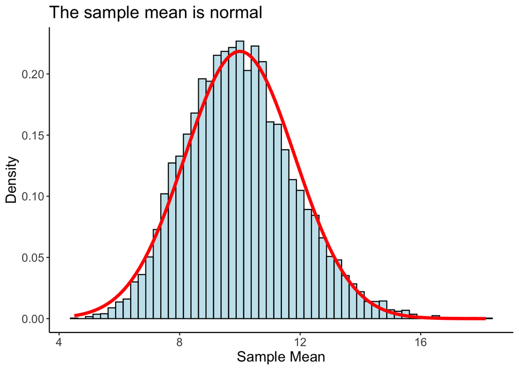

```r
# Generate 10000 sample means (each from 30 observation)
tibble(sample_mean = replicate(10000, {
  rexp(30, rate = 0.1) %>% mean()
})) %>%
  ggplot(aes(x = sample_mean)) +
  geom_histogram(aes(y = after_stat(density)), binwidth = 0.25,
                 color = "black", fill = "lightblue", alpha = 0.7) +
  stat_function(fun = ~ dnorm(., mean = 10, sd = 10/sqrt(30)),
                color = "red", linewidth = 1.5) +
  labs(x = "Sample Mean", y = "Density",
       title = "The sample mean is normal")
```

**Interpretation**: Even though the underlying distribution is very different (exponential), the distribution of sample means converges to a normal distribution.